# Homework 3

1. The expected value in an exponential distribution is 1/lamda. Therefore, the expected value is 10

```r
Xmean <- numeric(1000)

for(i in 1:1000)
{

current_sample <- rexp(30, rate = 1/10)

#store the mean of the five observations
Xmean[i] <- mean(current_sample)
}
```

```r
mean(Xmean)
```

```
## [1] 9.978026
```

```r
sd(Xmean)
```

```
## [1] 1.836891
```

```r
mean(Xmean >= 12)
```

```
## [1] 0.144
```

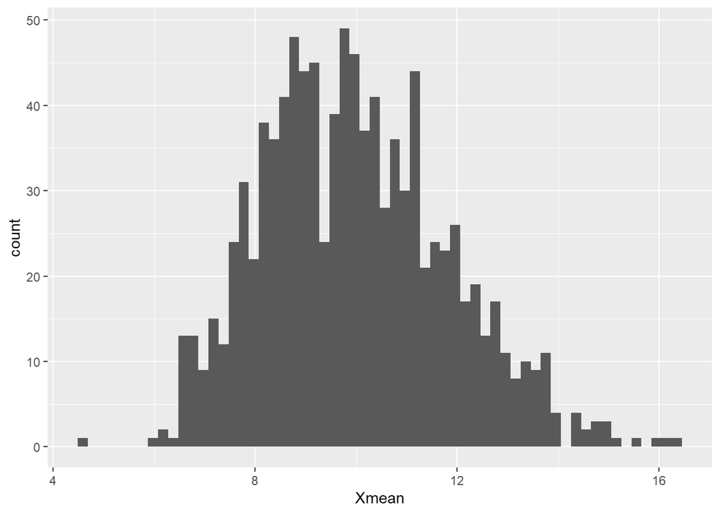

```r
ggplot(data=tibble(Xmean), mapping = aes(x=Xmean)) +
geom_histogram(bins = 60)
```

##Question 4.17

Assuming that both distribution is iid, we get W are normal distribution with mean of 7 and SD of 5. (Calculation is on the scratch paper uploaded)

```r
#mean.w = a. Ux + b.Uy
mean.w = (1* 15) - (2*4)
mean.w   #The mean of w is 7
```

```
## [1] 7
```

```r
#variance.w = a^2.(Sdx)^2 + (b^2)*(sdY)^2
variance.w = ((1)^2 * 3^2) + ((-2)^2 * (2)^2)
variance.w #The variance is 25
```

```
## [1] 25
```

```r
#The SD is 5
# w is norm(7,5)
```

Running the stimulation,

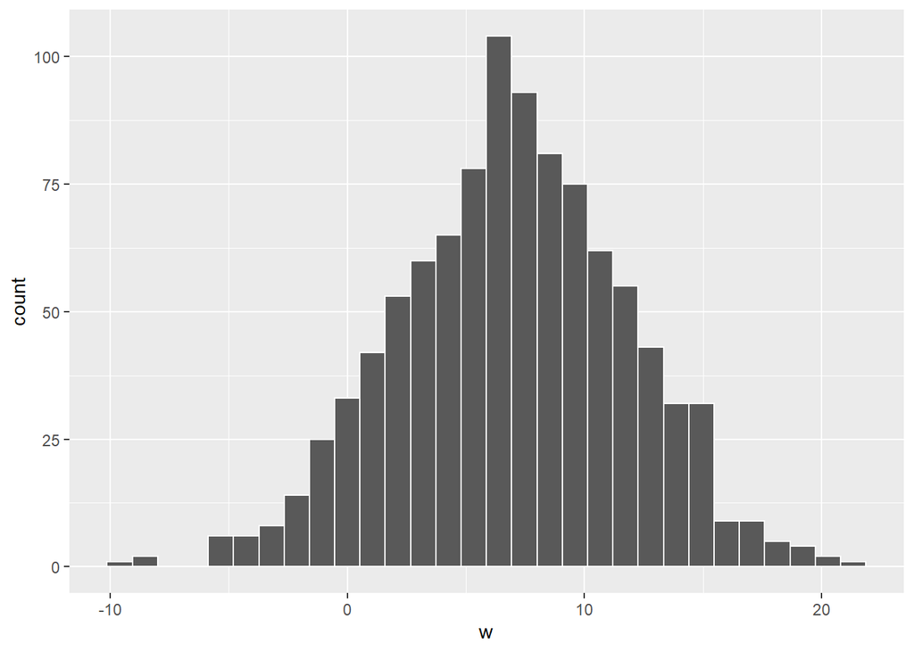

```r
set.seed(1000)

current_sample_X <- rnorm(1000, mean = 15, sd = 3)
current_sample_y <- rnorm(1000, mean = 4, sd = 2)

w <- current_sample_X - (2 * current_sample_y)


#plot a histogram of the simulated values
ggplot(data=tibble(w), mapping = aes(x = w)) +
geom_histogram(color="white")
```

```r
wmean = mean(w)
wmean #Mean is 6.95
```

```
## [1] 6.959518
```

```r
SD.w = sd(w)
SD.w #SD is 4.811
```

```
## [1] 4.811461
```

Simulated y

```r
y = pnorm(10, mean = wmean, sd = SD.w)
y
```

```
## [1] 0.736282
```

```r
#theory
mean (w <= 10)
```

```
## [1] 0.736
```

The p value is 0.736 So when we compare both values ,they are approximately same at 3 decimal places.

## Question 4.28

Calculate f(x) min is n*(1-(F(x)^n-1)* F(x) our given f(x) is 3x^2 , so to calcualte the cdf i.e F(x), we need to integrate the 3x^2 integration of 3t^2 is 3t^3/3 = t^3

Therefore, the minimum us n*((1-t<sup>3))</sup>n-1. 3X^2

2. maximum: maximum = n.F(x).f(x) n*(t<sup>2)</sup>n-1* 3 t^2 = n.t ^2n* t ^-2 * 3*t ^2 = 3*n*t^(2n)
3. Calculating the fx(max) where the value of x is 0.92 From the formula, we know that the FX is x^3 and F(x<= max) is Fx^n so max is (x^3) ^n

```r
# max <- ((0.92)^3)^10  = o.92^30
maxf <- (0.92)^30
maxf
```

```
## [1] 0.0819662
```

So, maxf is 0.081 but since we are interested in greater than 0.92, we need to subtract the probabiltiy from 1

```r
Prob <- 1 - maxf
Prob
```

```
## [1] 0.9180338
```

Therefore, the probability is 0.918